[figure not shown]

# CSCI 416-01/516-01: Fundamentals of AI/ML

# Fall 2025

# Model evaluation and tuning

## The Wisconsin cancer dataset

We will use the Wisconsin cancer dataset.

```python
from sklearn.datasets import load_breast_cancer

data = load_breast_cancer()

print(data.DESCR)
print("Feature names: ", data.feature_names)
print("Target names:  ", data.target_names)
```

```
.. _breast_cancer_dataset:

Breast cancer Wisconsin (diagnostic) dataset
--------------------------------------------

**Data Set Characteristics:**

:Number of Instances: 569

:Number of Attributes: 30 numeric, predictive attributes and the class

:Attribute Information:
    - radius (mean of distances from center to points on the perimeter)
    - texture (standard deviation of gray-scale values)
    - perimeter
    - area
    - smoothness (local variation in radius lengths)
    - compactness (perimeter^2 / area - 1.0)
    - concavity (severity of concave portions of the contour)
    - concave points (number of concave portions of the contour)
    - symmetry
    - fractal dimension ("coastline approximation" - 1)

    The mean, standard error, and "worst" or largest (mean of the three
    worst/largest values) of these features were computed for each image,
    resulting in 30 features.  For instance, field 0 is Mean Radius, field
    10 is Radius SE, field 20 is Worst Radius.

    - class:
            - WDBC-Malignant
            - WDBC-Benign

:Summary Statistics:

===================================== ====== ======
                                        Min    Max
===================================== ====== ======
radius (mean):                        6.981  28.11
texture (mean):                       9.71   39.28
perimeter (mean):                     43.79  188.5
```

[output cut: 74 more lines]

```
    July-August 1995.
  - W.H. Wolberg, W.N. Street, and O.L. Mangasarian. Machine learning techniques
    to diagnose breast cancer from fine-needle aspirates. Cancer Letters 77 (1994)
    163-171.

Feature names:  ['mean radius' 'mean texture' 'mean perimeter' 'mean area'
 'mean smoothness' 'mean compactness' 'mean concavity'
 'mean concave points' 'mean symmetry' 'mean fractal dimension'
 'radius error' 'texture error' 'perimeter error' 'area error'
 'smoothness error' 'compactness error' 'concavity error'
 'concave points error' 'symmetry error' 'fractal dimension error'
 'worst radius' 'worst texture' 'worst perimeter' 'worst area'
 'worst smoothness' 'worst compactness' 'worst concavity'
 'worst concave points' 'worst symmetry' 'worst fractal dimension']
Target names:   ['malignant' 'benign']
```

```python
X = data.data
y = data.target
print(X[0:9,:])
print(y[0:9])
```

```
[[1.799e+01 1.038e+01 1.228e+02 1.001e+03 1.184e-01 2.776e-01 3.001e-01
  1.471e-01 2.419e-01 7.871e-02 1.095e+00 9.053e-01 8.589e+00 1.534e+02
  6.399e-03 4.904e-02 5.373e-02 1.587e-02 3.003e-02 6.193e-03 2.538e+01
  1.733e+01 1.846e+02 2.019e+03 1.622e-01 6.656e-01 7.119e-01 2.654e-01
  4.601e-01 1.189e-01]
 [2.057e+01 1.777e+01 1.329e+02 1.326e+03 8.474e-02 7.864e-02 8.690e-02
  7.017e-02 1.812e-01 5.667e-02 5.435e-01 7.339e-01 3.398e+00 7.408e+01
  5.225e-03 1.308e-02 1.860e-02 1.340e-02 1.389e-02 3.532e-03 2.499e+01
  2.341e+01 1.588e+02 1.956e+03 1.238e-01 1.866e-01 2.416e-01 1.860e-01
  2.750e-01 8.902e-02]
 [1.969e+01 2.125e+01 1.300e+02 1.203e+03 1.096e-01 1.599e-01 1.974e-01
  1.279e-01 2.069e-01 5.999e-02 7.456e-01 7.869e-01 4.585e+00 9.403e+01
  6.150e-03 4.006e-02 3.832e-02 2.058e-02 2.250e-02 4.571e-03 2.357e+01
  2.553e+01 1.525e+02 1.709e+03 1.444e-01 4.245e-01 4.504e-01 2.430e-01
  3.613e-01 8.758e-02]
 [1.142e+01 2.038e+01 7.758e+01 3.861e+02 1.425e-01 2.839e-01 2.414e-01
  1.052e-01 2.597e-01 9.744e-02 4.956e-01 1.156e+00 3.445e+00 2.723e+01
  9.110e-03 7.458e-02 5.661e-02 1.867e-02 5.963e-02 9.208e-03 1.491e+01
  2.650e+01 9.887e+01 5.677e+02 2.098e-01 8.663e-01 6.869e-01 2.575e-01
  6.638e-01 1.730e-01]
 [2.029e+01 1.434e+01 1.351e+02 1.297e+03 1.003e-01 1.328e-01 1.980e-01
  1.043e-01 1.809e-01 5.883e-02 7.572e-01 7.813e-01 5.438e+00 9.444e+01
  1.149e-02 2.461e-02 5.688e-02 1.885e-02 1.756e-02 5.115e-03 2.254e+01
  1.667e+01 1.522e+02 1.575e+03 1.374e-01 2.050e-01 4.000e-01 1.625e-01
  2.364e-01 7.678e-02]
 [1.245e+01 1.570e+01 8.257e+01 4.771e+02 1.278e-01 1.700e-01 1.578e-01
  8.089e-02 2.087e-01 7.613e-02 3.345e-01 8.902e-01 2.217e+00 2.719e+01
  7.510e-03 3.345e-02 3.672e-02 1.137e-02 2.165e-02 5.082e-03 1.547e+01
  2.375e+01 1.034e+02 7.416e+02 1.791e-01 5.249e-01 5.355e-01 1.741e-01
  3.985e-01 1.244e-01]
 [1.825e+01 1.998e+01 1.196e+02 1.040e+03 9.463e-02 1.090e-01 1.127e-01
  7.400e-02 1.794e-01 5.742e-02 4.467e-01 7.732e-01 3.180e+00 5.391e+01
  4.314e-03 1.382e-02 2.254e-02 1.039e-02 1.369e-02 2.179e-03 2.288e+01
  2.766e+01 1.532e+02 1.606e+03 1.442e-01 2.576e-01 3.784e-01 1.932e-01
  3.063e-01 8.368e-02]
 [1.371e+01 2.083e+01 9.020e+01 5.779e+02 1.189e-01 1.645e-01 9.366e-02
  5.985e-02 2.196e-01 7.451e-02 5.835e-01 1.377e+00 3.856e+00 5.096e+01
  8.805e-03 3.029e-02 2.488e-02 1.448e-02 1.486e-02 5.412e-03 1.706e+01
  2.814e+01 1.106e+02 8.970e+02 1.654e-01 3.682e-01 2.678e-01 1.556e-01
  3.196e-01 1.151e-01]
 [1.300e+01 2.182e+01 8.750e+01 5.198e+02 1.273e-01 1.932e-01 1.859e-01
  9.353e-02 2.350e-01 7.389e-02 3.063e-01 1.002e+00 2.406e+00 2.432e+01
  5.731e-03 3.502e-02 3.553e-02 1.226e-02 2.143e-02 3.749e-03 1.549e+01
  3.073e+01 1.062e+02 7.393e+02 1.703e-01 5.401e-01 5.390e-01 2.060e-01
  4.378e-01 1.072e-01]]
[0 0 0 0 0 0 0 0 0]
```

The version of the dataset in Scikit-Learn does not explain this, but the label 0 means **malignant** and label 1 means **benign**. I find this confusing, so let's reverse the labels:

```python
y = (y == 0)

print(y[0:9])
```

```
[ True  True  True  True  True  True  True  True  True]
```

```python
print(X.shape)
```

```
(569, 30)
```

## Create training and test sets

We will use a 70/30 training/test split.

```python
from sklearn.model_selection import train_test_split

X_train, X_test, y_train, y_test = train_test_split(X, y, test_size=0.3, random_state=42)
```

## Combining transformers and estimators in a pipeline

Our pipeline will consist of (in order):

1. the standard scaler (mean 0, variance 1), and
2. a logistic regression classifier.

We will also fit and test the model.

```python
from sklearn.preprocessing import StandardScaler
from sklearn.linear_model import LogisticRegression
from sklearn.pipeline import Pipeline

pipe_lr = Pipeline([('scl', StandardScaler()),
            ('clf', LogisticRegression(random_state=42))])

pipe_lr.fit(X_train, y_train)
print(f"Test Accuracy: {pipe_lr.score(X_test, y_test):.3f}")
```

```
Test Accuracy: 0.982
```

# Using k-fold cross-validation to assess model performance

[**Cross-validation**](http://scikit-learn.org/stable/modules/cross_validation.html) is one approach to assessing model performance. Cross-validation allows us to assess our model **before** we try it on the test set.

In basic k-fold cross-validation, we randomly partition the t training cases into k disjoint sets (**folds**) of size t/k.

We then treat, in turn, each of the k sets as a validation set.

For very small datasets one would typically choose t-fold cross-validation. That is, there are t validation sets, each of size 1. This is called **leave-out-one (LOO) validation**.

**Stratified k-fold cross-validation** is a variation of k-fold cross-validation that can yield better results, particulary when the class proportions are markedly unequal. In stratified cross-validation, the class proportions are preserved in each fold. This ensures that each fold is representative of the class proportions in the training dataset.

The term "stratified" comes from **stratified sampling**. In stratified sampling, each sub-population, or stratum, is sampled independently so that the sample proportions will reflect the population proportions. Stratification refers to the process of dividing the population into disjoint, homogeneous subgroups before sampling.

We will use stratified cross-validation as implemented in the [StratifiedKFold class](http://scikit-learn.org/stable/modules/generated/sklearn.model_selection.StratifiedKFold.html#sklearn.model_selection.StratifiedKFold) to evaluate our classifier.

```python
import numpy as np

print('no. of benign cases:   ', np.sum(y_train == 0))
print('no. of malignant cases:', np.sum(y_train == 1))
```

```
no. of benign cases:    249
no. of malignant cases: 149
```

```python
import numpy as np
from sklearn.model_selection import StratifiedKFold

skfold = StratifiedKFold(n_splits=10)

scores = []
for k, (train, test) in enumerate(skfold.split(X_train, y_train)):
    pipe_lr.fit(X_train[train], y_train[train])
    score = pipe_lr.score(X_train[test], y_train[test])
    scores.append(score)
    print(f"Fold: {k+1:2d}, Class distributions: {str(np.bincount(y_train[train])):s}, Accuracy: {score:f}")

print()
print(f"Cross-validation accuracy: {np.mean(scores):.3f} +/- {np.std(scores):.3f}")
```

```
Fold:  1, Class distributions: [224 134], Accuracy: 0.975000
Fold:  2, Class distributions: [224 134], Accuracy: 0.975000
Fold:  3, Class distributions: [224 134], Accuracy: 0.975000
Fold:  4, Class distributions: [224 134], Accuracy: 1.000000
Fold:  5, Class distributions: [224 134], Accuracy: 1.000000
Fold:  6, Class distributions: [224 134], Accuracy: 1.000000
Fold:  7, Class distributions: [224 134], Accuracy: 0.975000
Fold:  8, Class distributions: [224 134], Accuracy: 0.950000
Fold:  9, Class distributions: [224 135], Accuracy: 0.923077
Fold: 10, Class distributions: [225 134], Accuracy: 0.974359

Cross-validation accuracy: 0.975 +/- 0.023
```

We can obtain the same cross-validation score more succinctly using scikit-learn's [cross_val_score()](http://scikit-learn.org/stable/modules/generated/sklearn.model_selection.cross_val_score.html#sklearn.model_selection.cross_val_score) method.

```python
from sklearn.model_selection import cross_val_score

scores = cross_val_score(estimator=pipe_lr,
                         X=X_train,
                         y=y_train,
                         cv=10,
                         n_jobs=1)
print(f"CV accuracy scores: {str(scores):s}")
print(f"CV accuracy: {np.mean(scores):.3f} +/- {np.std(scores):.3f}")
```

```
CV accuracy scores: [0.975      0.975      0.975      1.         1.         1.
 0.975      0.95       0.92307692 0.97435897]
CV accuracy: 0.975 +/- 0.023
```

Cross-validation is "embarassingly parallel" and the calculations for each fold can be spread across multiple processors independently. We can set the number of cores/processors to use with the `n_jobs` argument.

# Debugging algorithms with learning curves

An ML model must navigate the Scylla and Charybdis of **bias** and **variance**.

Bias means we underfit the data due to modeling errors or other deficiencies in our model. **Bias typically decreases with model complexity – more complex models are capable of capturing more features of the problem**.

Variance refers to how our model's performance varies from one set of data to another. **Variance increases with model complexity – in general, the more complex a model, the more sensitive it becomes to the choice of training data, and the more likely it is that the model will not generalize to new data because of overfitting to the training set**.

There is a trade-off between bias and variance: a certain level of model complexity is needed to avoid bias, but too complex a model will suffer from high variance.

## Diagnosing bias and variance problems with learning curves

We can understand the bias and variance behavior of our model by examining how it does on training/test sets of varying size.

- We look at the trends of performance on the training and test sets as the size of each increases.
- When both sets are small, we should not expect great results. But what happens as the size increases?
- If the bias is large, we should not expect good performance for either the training set or the test set. 🙁 🙁
- If the variance is high, we should see good performance on the training set but significantly poorer performance on the test set. 🙂 🙁

Ideally we will have low bias and low variance achieving good accuracy on both the training and test sets. 🙂 🙂

In Scikit-Learn we can generate plots like this using the `learning_curve()` function.

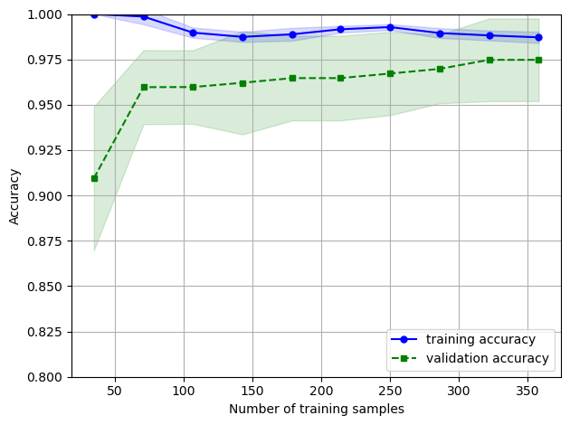

```python
%matplotlib inline
import matplotlib.pyplot as plt
from sklearn.model_selection import learning_curve

pipe_lr = Pipeline([('scl', StandardScaler()),
            ('clf', LogisticRegression(penalty='l2', random_state=0))])

train_sizes, train_scores, test_scores = \
                learning_curve(estimator=pipe_lr,
                X=X_train,
                y=y_train,
                train_sizes=np.linspace(0.1, 1.0, 10),
                cv=10,
                n_jobs=1)

train_mean = np.mean(train_scores, axis=1)
train_std  = np.std(train_scores, axis=1)
test_mean  = np.mean(test_scores, axis=1)
test_std   = np.std(test_scores, axis=1)

plt.plot(train_sizes, train_mean,
         color='blue', marker='o',
         markersize=5, label='training accuracy')

plt.fill_between(train_sizes,
                 train_mean + train_std,
                 train_mean - train_std,
                 alpha=0.15, color='blue')

plt.plot(train_sizes, test_mean,
         color='green', linestyle='--',
         marker='s', markersize=5,
         label='validation accuracy')

plt.fill_between(train_sizes,
                 test_mean + test_std,
                 test_mean - test_std,
                 alpha=0.15, color='green')

plt.grid()
plt.xlabel('Number of training samples')
plt.ylabel('Accuracy')
plt.legend(loc='lower right')
plt.ylim([0.8, 1.0])
plt.tight_layout()
# plt.savefig('./figures/learning_curve.png', dpi=300)
plt.show()
```

How does this classifier do with regards to bias (underfitting) and variance (overfitting)?

Bias: 🙂

Variance: 🙂

# Addressing overfitting and underfitting with validation curves

We can often address overfitting (variance) and underfitting (bias) by tuning hyperparameters in our model during training.

We can see the effects of changing one hyperparameter using Scikit-Learn's `validation_curve()` function.

Let's look at logistic regression. The problem being solved in [training the scikit-learn implementation of logistic regression](http://scikit-learn.org/stable/modules/linear_model.html#logistic-regression) for binary classification is $$ \newcommand{\norm}[1]{\| #1 \|} \newcommand{\minimize}{\mbox{minimize}} \minimize_{w,b} \sum_{i=1}^{N} \log\left(1 + \exp(y_{i}(x_{i}^{T}w + b))\right) + \frac{1}{C} \norm{w}_{2}^{2}. $$ The term in the summation is the negative of the log-likelihood function (minimizing the negative is equivalent to maximizing the log-likelihood), with $y_{i} = \pm 1$ being the class indicators. We used this trick to simplify notation for SVC (compare the preceding with the formulation in the notes).

$\newcommand{\twonorm}[1]{\norm{#1}_{2}}$ The term $\frac{1}{C} \twonorm{w}$ is a **regularization** or **penalty** terms that keep the model parameters from becoming too big.

The weight $1/C$ controls the tradeoff between keeping $w$ small (a simpler model with more bias and less variance) and minimizing the negative log-likelihood (a more complex model with less bias and more variance).

If $C$ is small, we are placing a greater emphasis on reducing variance; if $C$ is large we are are placing a greater emphasis on reducing bias.

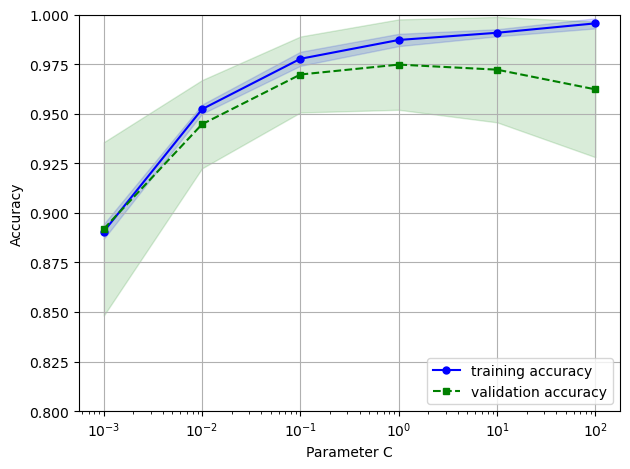

```python
from sklearn.model_selection import validation_curve

param_values = [0.001, 0.01, 0.1, 1.0, 10.0, 100.0]
train_scores, test_scores = validation_curve(
                estimator=pipe_lr,
                X=X_train,
                y=y_train,
                param_name='clf__C',
                param_range=param_values,
                cv=10)

train_mean = np.mean(train_scores, axis=1)
train_std = np.std(train_scores, axis=1)
test_mean = np.mean(test_scores, axis=1)
test_std = np.std(test_scores, axis=1)

plt.plot(param_values, train_mean,
         color='blue', marker='o',
         markersize=5, label='training accuracy')

plt.fill_between(param_values, train_mean + train_std,
                 train_mean - train_std, alpha=0.15,
                 color='blue')

plt.plot(param_values, test_mean,
         color='green', linestyle='--',
         marker='s', markersize=5,
         label='validation accuracy')

plt.fill_between(param_values,
                 test_mean + test_std,
                 test_mean - test_std,
                 alpha=0.15, color='green')

plt.grid()
plt.xscale('log')
plt.legend(loc='lower right')
plt.xlabel('Parameter C')
plt.ylabel('Accuracy')
plt.ylim([0.8, 1.0])
plt.tight_layout()
plt.show()
```

- When $C$ is small, the accuracies for the training and validation sets are similar, but the accuracy is lower than we can achieve for other values of $C$. This is a sign of higher bias (underfitting), but lower variance (overfitting).
- As $C$ increases, we obtain higher accuracy (lower bias) but performance on the two sets begins to diverge. This is a sign of decreasing bias, but increasing variance (overfitting).
- When $C$ is large, we obtain higher accuracy on the training set but decreasing accuracy on the validation set. This is a sign of increasing variance and overfitting.

# Tuning hyperparameters via grid search

We can tune the hyperparameter values for our ML algorithms by searching over a grid of candidate values.

The search is embarassingly parallel, so we can distribute it over multiple cores/processors.

On the other hand, the number of models we need to train can grow quickly: if we are changing, say, 6 hyperparameters, and we want to try 10 values for each, then we have a $10 \times 10 \times 10 \times 10 \times 10 \times 10$ grid, which has $10^{6}$ grid points!

We can perform exhaustive grid search using scikit-learn's [`GridSearchCV()`](http://scikit-learn.org/stable/modules/generated/sklearn.model_selection.GridSearchCV.html) function. Rather than train on a single model for each value of the hyperparameters, `GridSearchCV()` evaluates each model using cross-validation. By default it uses three-fold stratified cross-validation.

```python
from sklearn.model_selection import GridSearchCV
from sklearn.svm import SVC

pipe_svc = Pipeline([('scl', StandardScaler()),
                     ('clf', SVC(random_state=1))])

param_range = [0.0001, 0.001, 0.01, 0.1, 1.0, 10.0, 100.0, 1000.0]

param_grid = [{'clf__C': param_range,
               'clf__kernel': ['linear']},
                 {'clf__C': param_range,
                  'clf__gamma': param_range,
                  'clf__kernel': ['rbf']}]

gs = GridSearchCV(estimator=pipe_svc,
                  param_grid=param_grid,
                  scoring='accuracy',
                  cv=10,
                  n_jobs=-1)  # n_jobs = -1 means use all cores
gs = gs.fit(X_train, y_train)
print(f"{gs.best_score_:.3f}")
print(gs.best_params_)
```

```
0.972
{'clf__C': 1000.0, 'clf__gamma': 0.0001, 'clf__kernel': 'rbf'}
```

```python
clf = gs.best_estimator_
clf.fit(X_train, y_train)
print(f"Test accuracy: {clf.score(X_test, y_test):.3f}")
```

```
Test accuracy: 0.982
```